# Reproducible Research: Peer Assessment 1

Carlos Guadián

12/2/2021

```r
knitr::opts_chunk$set(echo = TRUE)
```

## Load & process data

First load data into `activity` variable

```r
activity <- read.csv("~/RepData_PeerAssessment1/activity.csv")
```

Check for correct class of variables

```r
str(activity)
```

```
## 'data.frame':    17568 obs. of  3 variables:
##  $ steps   : int  NA NA NA NA NA NA NA NA NA NA ...
##  $ date    : chr  "2012-10-01" "2012-10-01" "2012-10-01" "2012-10-01" ...
##  $ interval: int  0 5 10 15 20 25 30 35 40 45 ...
```

`date` variable has class character, and it has to be “Date”.

```r
activity$date <- as.Date(activity$date)
```

Check again

```r
str(activity)
```

```
## 'data.frame':    17568 obs. of  3 variables:
##  $ steps   : int  NA NA NA NA NA NA NA NA NA NA ...
##  $ date    : Date, format: "2012-10-01" "2012-10-01" ...
##  $ interval: int  0 5 10 15 20 25 30 35 40 45 ...
```

## What is mean total number of steps taken per day?

**Calculate the total number of steps taken per day**

To calculate the total number of steps taken per day first I have to group data by day. To do this we need the `tidyverse` library.

```r
library(tidyverse)
steps_by_day <- activity %>%
  group_by(date) %>%
  summarize(total_steps = sum(steps))
head(steps_by_day)
```

```
## # A tibble: 6 × 2
##   date       total_steps
##   <date>           <int>
## 1 2012-10-01          NA
## 2 2012-10-02         126
## 3 2012-10-03       11352
## 4 2012-10-04       12116
## 5 2012-10-05       13294
## 6 2012-10-06       15420
```

**Make a histogram of the total number of steps taken each day**

Making histogram with base system

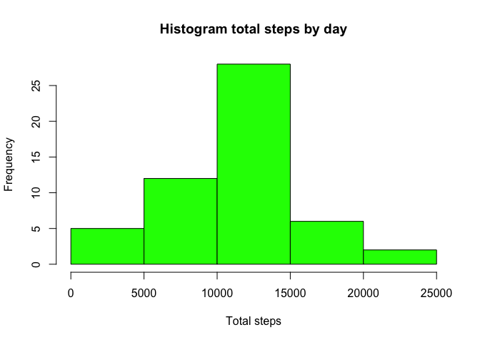

Histogram of total steps by day

```r
with(steps_by_day, {
  hist(total_steps, col = "green", main = "Histogram total steps by day", xlab = "Total steps")
})
```

**Calculate and report the mean and median of the total number of steps taken per day** Using two ways to get mean and median. With `summary` and `mean()` & `median()`

```r
summary(steps_by_day$total_steps)
```

```
##    Min. 1st Qu.  Median    Mean 3rd Qu.    Max.    NA's
##      41    8841   10765   10766   13294   21194       8
```

```r
mean(steps_by_day$total_steps, na.rm = TRUE)
```

```
## [1] 10766.19
```

```r
median(steps_by_day$total_steps, na.rm = TRUE)
```

```
## [1] 10765
```

## What is the average daily activity pattern?

**Make a time series plot (i.e. type = “l”) of the 5-minute interval (x-axis) and the average number of steps taken, averaged across all days (y-axis)**

Group by interval to get average number of steps by interval

```r
steps_by_interval <- activity %>%
  group_by(interval) %>%
  summarize(average_steps = mean(steps, na.rm = TRUE))
head(steps_by_interval)
```

```
## # A tibble: 6 × 2
##   interval average_steps
##      <int>         <dbl>
## 1        0        1.72
## 2        5        0.340
## 3       10        0.132
## 4       15        0.151
## 5       20        0.0755
## 6       25        2.09
```

Plotting time serie

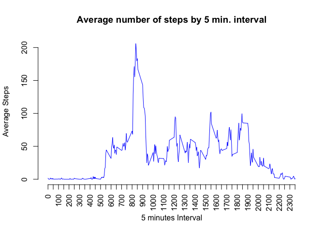

```r
with(steps_by_interval, {
plot(interval, average_steps, type = "l",
     main = "Average number of steps by 5 min. interval", xlab = "5 minutes Interval", ylab = "Average Steps", col = "blue", lwd = 1, frame.plot=FALSE, xaxt="n")
  axis(1, at = seq(00, 2355, by = 50), las=2)
  })
```

**Which 5-minute interval, on average across all the days in the dataset, contains the maximum number of steps?** Getting the interval filtering with `which.max()`

```r
max_steps_interval <- steps_by_interval[which.max(steps_by_interval$average_steps),]
max_steps_interval
```

```
## # A tibble: 1 × 2
##   interval average_steps
##      <int>         <dbl>
## 1      835          206.
```

Adding vertical line to check if interval 835 has the maximum steps in graph

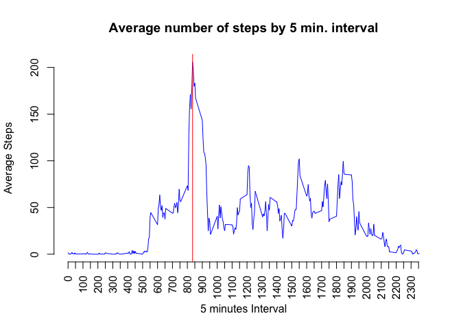

Average number of steps by 5 min. interval

```r
with(steps_by_interval, {
plot(interval, average_steps, type = "l",
     main = "Average number of steps by 5 min. interval", xlab = "5 minutes Interval", ylab = "Average Steps", col = "blue", lwd = 1, frame.plot=FALSE, xaxt="n")
  axis(1, at = seq(00, 2355, by = 50), las=2)
  abline(v=835, col = "red", lwd = 1)
  })
```

## Imputing missing values

Note that there are a number of days/intervals where there are missing values (**coded as NA**). The presence of missing days may introduce bias into some calculations or summaries of the data.

**Calculate and report the total number of missing values in the dataset (i.e. the total number of rows with NAs)** The only variable in `activity` dataset with NAs is `steps`, we can check this with `summary`, and then we can confirm with `sum(is.na())`

```r
summary(activity)
```

```
##      steps             date               interval
##  Min.   :  0.00   Min.   :2012-10-01   Min.   :   0.0
##  1st Qu.:  0.00   1st Qu.:2012-10-16   1st Qu.: 588.8
##  Median :  0.00   Median :2012-10-31   Median :1177.5
##  Mean   : 37.38   Mean   :2012-10-31   Mean   :1177.5
##  3rd Qu.: 12.00   3rd Qu.:2012-11-15   3rd Qu.:1766.2
##  Max.   :806.00   Max.   :2012-11-30   Max.   :2355.0
##  NA's   :2304
```

```r
sum(is.na(activity$steps))
```

```
## [1] 2304
```

**Create a new dataset that is equal to the original dataset but with the missing data filled in.**

**Devise a strategy for filling in all of the missing values in the dataset. The strategy does not need to be sophisticated. For example, you could use the mean/median for that day, or the mean for that 5-minute interval, etc.**

To replace NA we get the mean of each interval and then substitute the NA for this new data.

```r
library(dplyr)
# Create new dataset to fill NA values
intervals <- activity
# Groupping and replacing
intervals <- intervals %>%
  left_join(intervals %>%
              group_by(interval) %>%
              summarise(mean_steps = mean(steps, na.rm = TRUE))) %>%
  mutate(steps = ifelse(is.na(steps), mean_steps, steps)) %>%
  select(-mean_steps)
```

Check if the replace are OK

```r
# First if there are NA values
summary(intervals)
```

```
##      steps             date               interval
##  Min.   :  0.00   Min.   :2012-10-01   Min.   :   0.0
##  1st Qu.:  0.00   1st Qu.:2012-10-16   1st Qu.: 588.8
##  Median :  0.00   Median :2012-10-31   Median :1177.5
##  Mean   : 37.38   Mean   :2012-10-31   Mean   :1177.5
##  3rd Qu.: 27.00   3rd Qu.:2012-11-15   3rd Qu.:1766.2
##  Max.   :806.00   Max.   :2012-11-30   Max.   :2355.0
```

```r
sum(is.na(intervals$steps))
```

```
## [1] 0
```

**Make a histogram of the total number of steps taken each day**

To calculate the total number of steps taken per day first I have to group data by day. To do this we need the `tidyverse` library.

```r
steps_by_day_clean <- intervals %>%
  group_by(date) %>%
  summarize(total_steps = sum(steps))
head(steps_by_day_clean)
```

```
## # A tibble: 6 × 2
##   date       total_steps
##   <date>           <dbl>
## 1 2012-10-01      10766.
## 2 2012-10-02        126
## 3 2012-10-03      11352
## 4 2012-10-04      12116
## 5 2012-10-05      13294
## 6 2012-10-06      15420
```

Making histogram

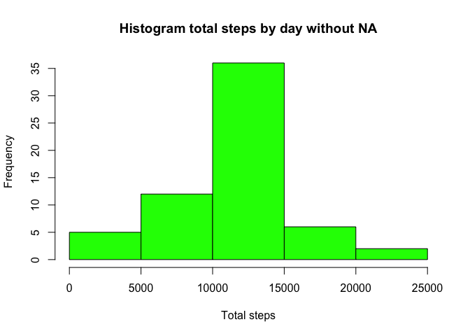

```r
with(steps_by_day_clean, {
  hist(total_steps, col = "green", main = "Histogram total steps by day without NA", xlab = "Total steps")
})
```

**Calculate and report the mean and median total number of steps taken per day**

```r
summary(steps_by_day_clean$total_steps)
```

```
##    Min. 1st Qu.  Median    Mean 3rd Qu.    Max.
##      41    9819   10766   10766   12811   21194
```

```r
mean(steps_by_day_clean$total_steps, na.rm = TRUE)
```

```
## [1] 10766.19
```

```r
median(steps_by_day_clean$total_steps, na.rm = TRUE)
```

```
## [1] 10766.19
```

**Do these values differ from the estimates from the first part of the assignment?**

Comparing two values

```r
#comparing mean
identical(mean(steps_by_day$total_steps, na.rm = TRUE), mean(steps_by_day_clean$total_steps, na.rm = TRUE))
```

```
## [1] TRUE
```

```r
# comparing median
identical(median(steps_by_day$total_steps, na.rm = TRUE),median(steps_by_day_clean$total_steps, na.rm = TRUE))
```

```
## [1] FALSE
```

**What is the impact of imputing missing data on the estimates of the total daily number of steps?**

```r
# Summarizing
# With NA
summary(steps_by_day)
```

```
##       date             total_steps
##  Min.   :2012-10-01   Min.   :   41
##  1st Qu.:2012-10-16   1st Qu.: 8841
##  Median :2012-10-31   Median :10765
##  Mean   :2012-10-31   Mean   :10766
##  3rd Qu.:2012-11-15   3rd Qu.:13294
##  Max.   :2012-11-30   Max.   :21194
##                       NA's   :8
```

```r
#Without NA
summary(steps_by_day_clean)
```

```
##       date             total_steps
##  Min.   :2012-10-01   Min.   :   41
##  1st Qu.:2012-10-16   1st Qu.: 9819
##  Median :2012-10-31   Median :10766
##  Mean   :2012-10-31   Mean   :10766
##  3rd Qu.:2012-11-15   3rd Qu.:12811
##  Max.   :2012-11-30   Max.   :21194
```

## Are there differences in activity patterns between weekdays and weekends?

For this part the `weekdays()` function may be of some help here. Use the dataset with the filled-in missing values for this part.

Create a new factor variable in the dataset with two levels – “weekday” and “weekend” indicating whether a given date is a weekday or weekend day.

```r
# In order to get correct running if you don't have english locale, first set up
Sys.setlocale(locale="en_US.UTF-8")
```

```
## [1] "en_US.UTF-8/en_US.UTF-8/en_US.UTF-8/C/en_US.UTF-8/es_ES.UTF-8"
```

```r
#create a vector of weekdays
weekdays1 <- c('Monday', 'Tuesday', 'Wednesday', 'Thursday', 'Friday')
#Use `%in%` and `weekdays` to create a logical vector
#convert to `factor` and specify the `levels/labels`
intervals$wDay <- factor((weekdays(intervals$date) %in% weekdays1),
         levels=c(FALSE, TRUE), labels=c('weekend', 'weekday'))
table(intervals$wDay)
```

```
##
## weekend weekday
##    4608   12960
```

**Make a panel plot containing a time series plot type = “l” of the 5-minute interval (x-axis) and the average number of steps taken, averaged across all weekday days or weekend days (y-axis).**

Grouping by interval and wDay

```r
weekday_vs_weekend <- intervals %>%
  group_by(interval, wDay) %>%
  summarise(steps_mean = mean(steps))
weekday_vs_weekend
```

```
## # A tibble: 576 × 3
## # Groups:   interval [288]
##    interval wDay    steps_mean
##       <int> <fct>        <dbl>
##  1        0 weekend    0.215
##  2        0 weekday    2.25
##  3        5 weekend    0.0425
##  4        5 weekday    0.445
##  5       10 weekend    0.0165
##  6       10 weekday    0.173
##  7       15 weekend    0.0189
##  8       15 weekday    0.198
##  9       20 weekend    0.00943
## 10       20 weekday    0.0990
## # … with 566 more rows
```

Plotting panel to compare weedays with weekend

```r
library(lattice)
table(weekday_vs_weekend$wDay)
```

```
##
## weekend weekday
##     288     288
```

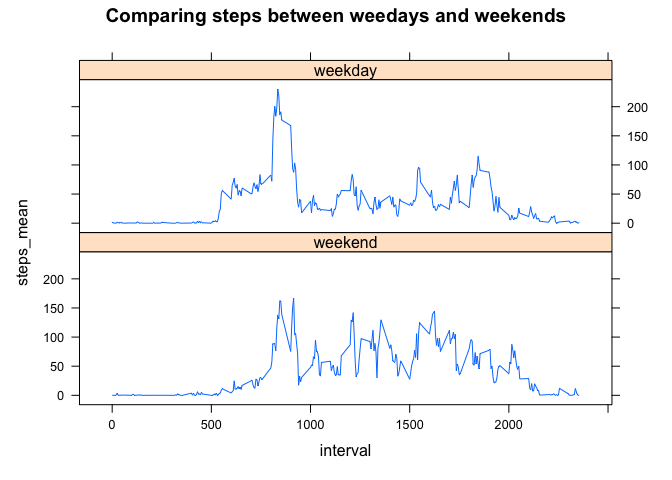

```r
with(weekday_vs_weekend, {
  xyplot(steps_mean ~ interval | wDay, type = "l", layout = c(1,2), main = "Comparing steps between weedays and weekends")
})
```

`That's all`